# Laporan 3 BTR dalam Media

Ujang fahmi

5/20/2018

# 1 Pendahuluan

Berdasarkan penuturan salah seorang partisipan penelitian, media sosial dipilih sebagai salah satu media untuk menyebarluaskan pesan penolakan reklamasi teluk benoa karena covering media arus utama kurang memadai. Oleh karena itu di sini saya akan mencoba mengonfirmasi pendapat tersebut. Selain itu, pemberitaan di media masa juga digunakan untuk mengetahui cerita tentang BTR dari sudut pandang lain.

Berita yang digunakan bersumber dari media lokal dan nasional. Media lokal terdiri dari balipost dan berita bali. Sedangkan berita nasional bersumber dari tempo dan kompas. Berita didapat dengan metode scrapping yang meliputi semua berita dengan kata kunci **reklamasi teluk benoa** yang pernah diterbitkan oleh media-media tersebut di atas. Namun untuk kompas dan tempo hanya bisa mendapatkan berita dalam 10 halaman terakhir saja karena adanya pembatasan pencarian berita. Berikut adalah perbandingan berita dari masing-masing sumber.

```r
# Runing RJava
if (Sys.info()['sysname'] == 'Darwin') {
  libjvm <- paste0(system2('/usr/libexec/java_home',stdout = TRUE)[1],'/jre/lib/server/libjvm.dylib')
  message (paste0('Load libjvm.dylib from: ',libjvm))
  dyn.load(libjvm)
}
library(ggplot2)
library(tidyverse)
library(tidytext)
library(Hmisc)
library(corrgram)
library(tm)
library(RWeka)
library(topicmodels)
library(googledrive)
library(SnowballC)
library(kableExtra)
```

```r
id_media <- "1MI7WGILkpdyLt8iU9-7NUwr7d5yv0UnJ" # cleaned username_all
media_data <- read_csv(sprintf("https://docs.google.com/uc?id=%s&export=download", id_media))
```

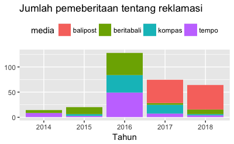

```r
media_data %>%
  select(tanggal, media) %>%
  separate(tanggal, into = c("tahun", "bulan", "tanggal"), sep = "-") %>%
  group_by(tahun) %>%
  count(media) %>%
  ggplot(aes(tahun, n, fill = media)) +
  geom_col() + theme(legend.position="top") +
  ggtitle("Jumlah pemeberitaan tentang reklamasi") +
  labs(x = "Tahun", y = NULL)
```

[figure not shown]

Perbedaan tren tersebut secara tidak langsung dapat memunculkan asumi untuk membantah (menolak) adanya *echo chamber* antara media sosial dan media arus utama. Di mana media sosial cenderung mengikuti tren pemberitaan di media arus utama.

```r
a <- media_data %>%
  select(tanggal, media) %>%
  separate(tanggal, into = c("tahun", "bulan", "tanggal"), sep = "-") %>%
  group_by(tahun) %>%
  summarise(jumlah_berita = n())
b <- tb_raw %>%
  separate(date, into = c("tahun", "bulan", "tanggal"), sep = "-") %>%
  group_by(tahun) %>%
  count(tahun) %>%
  filter(!tahun == "2013") %>%
  filter(!tahun == "2012")
twit_media <- bind_cols(a, b) %>%
  select(tahun, jumlah_berita, jumlah_twit = n)
rm(a, b)
```

# 2 Term Frekuensi dan TF-IDF

## 2.1 Berita tempo.co

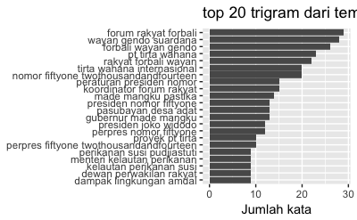

```r
media_data %>%
  filter(media == "tempo") %>%
  select(clean_text)%>%
  unnest_tokens(kata, clean_text, token = "ngrams", n = 3, to_lower = TRUE,
                drop = TRUE, collapse = NULL) %>%
  count(kata, sort = TRUE) %>%
  filter(!str_detect(kata, "teluk")) %>%
  filter(!str_detect(kata, "benoa")) %>%
  top_n(20) %>%
  ggplot(aes(reorder(kata, n), n)) + geom_col() + coord_flip() +
  ggtitle("top 20 trigram dari tempo.co") +
  labs(x = NULL, y = "Jumlah kata")
```

## 2.2 Berita kompas.com

Data dari kompas yang ada disini mulai dari tahun 2015 dengan 3 berita, 2016 dengan 35, 2017 dengan 17, dan 2018 sebanyak 2 berita.

```r
media_data %>%
  filter(media == "kompas") %>%
  select(clean_text)%>%
  unnest_tokens(kata, clean_text, token = "ngrams", n = 3, to_lower = TRUE,
                drop = TRUE, collapse = NULL) %>%
  count(kata, sort = TRUE) %>%
  filter(!str_detect(kata, "teluk")) %>%
  filter(!str_detect(kata, "benoa")) %>%
  filter(!str_detect(kata, "kompas")) %>%
  filter(!str_detect(kata, "com")) %>%
  top_n(20) %>%
  ggplot(aes(reorder(kata, n), n)) + geom_col() + coord_flip() +
  ggtitle("top 20 trigram dari kompas.com") +
  labs(x = NULL, y = "Jumlah kata")
```

[output not shown]

## 2.3 Berita balipost.com

```r
media_data %>%
  filter(media == "balipost") %>%
  select(clean_text)%>%
  unnest_tokens(kata, clean_text, token = "ngrams", n = 3, to_lower = TRUE,
                drop = TRUE, collapse = NULL) %>%
  count(kata, sort = TRUE) %>%
  filter(!str_detect(kata, "teluk")) %>%
  filter(!str_detect(kata, "benoa")) %>%
  filter(!str_detect(kata, "balipost")) %>%
  filter(!str_detect(kata, "zeroms")) %>%
  filter(!str_detect(kata, "opacity")) %>%
  filter(!str_detect(kata, "transition")) %>%
  filter(!str_detect(kata, "font")) %>%
  filter(!str_detect(kata, "weight")) %>%
  filter(!str_detect(kata, "bold")) %>%
  filter(!str_detect(kata, "onepx")) %>%
  filter(!str_detect(kata, "text")) %>%
  filter(!str_detect(kata, "decoration")) %>%
  filter(!str_detect(kata, "none")) %>%
  filter(!str_detect(kata, "important")) %>%
  top_n(20) %>%
  ggplot(aes(reorder(kata, n), n)) + geom_col() + coord_flip() +
  ggtitle("top 20 trigram dari balipost.com") +
  labs(x = NULL, y = "Jumlah kata")
```

[output not shown]

## 2.4 Berita beritabali.com

Pemberitaan tentang BTR dari beritabli dapat dikatakan rutin dilakukan dari tahun 2014 hingga 2018 awal ini. Secara urut (2014 - 2018) jumlah pemberitaan tentang BTR ada 5, 13, 44, 3, dan 9.

```r
media_data %>%
  filter(media=="beritabali") %>%
  #select(clean_text) %>%
  unnest_tokens(kata, clean_text, token = "ngrams", n = 3, to_lower = TRUE,
                drop = TRUE, collapse = NULL) %>%
  count(kata, sort = TRUE) %>%
  filter(!str_detect(kata, "teluk")) %>%
  filter(!str_detect(kata, "benoa")) %>%
  #filter(!str_detect(kata, "kompas")) %>%
  #filter(!str_detect(kata, "com")) %>%
  top_n(20) %>%
  ggplot(aes(reorder(kata, n), n)) + geom_col() + coord_flip() +
  ggtitle("top 20 trigram dari beritabali.com") +
  labs(x = NULL, y = "Jumlah kata")
```

[output not shown]

## 2.5 TF-IDF

```r
media_words <- media_data %>%
  group_by(media) %>%
  unnest_tokens(kata, clean_text, token = "ngrams", n = 3) %>%
  count(kata, sort = TRUE)

total_media <- media_words %>%
  group_by(media) %>%
  summarise(total = sum(n))

media_words <- left_join(media_words, total_media)

media_words <- media_words %>%
  bind_tf_idf(kata, media, n) %>%
  arrange(desc(tf_idf))

# Visualisasi tf-idf
media_words %>%
  arrange(desc(tf_idf)) %>%
  mutate(kata = factor(kata, levels = rev(unique(kata)))) %>%
  group_by(media) %>%
  top_n(7) %>%
  ungroup %>%
  ggplot(aes(reorder(kata,tf_idf), tf_idf, fill = media)) +
  geom_col(show.legend = FALSE) +
  facet_wrap(~media, ncol = 2, scales = "free") +
  labs(x = "Bigram", y = "Value") +
  coord_flip()
```

[output not shown]

# 3 Topic modelling

```r
bigram_tm <- function(input_text,
                       plot = T,
                       number_of_topics = 4)
{
  set.seed(2016)
  Corpus <- VCorpus(VectorSource(input_text))

  BigramTokenizer <- function(x) NGramTokenizer(x, Weka_control(min=2, max=3))
  DTM <- DocumentTermMatrix(Corpus, control=list(tokenize=BigramTokenizer))
  unique_indexes <- unique(DTM$i)
  DTM <- DTM[unique_indexes,]
  lda <- LDA(DTM, k = number_of_topics, control = list(seed = 1234))
  topics <- tidy(lda, matrix = "beta")
  top_terms <- topics  %>%
    group_by(topic) %>%
    top_n(10, beta) %>%
    ungroup() %>%
    arrange(topic, -beta)

  # if the user asks for a plot (TRUE by default)
  if(plot == T){
    top_terms %>%
      mutate(term = reorder(term, beta)) %>%
      ggplot(aes(term, beta, fill = factor(topic))) +
      geom_col(show.legend = FALSE) +
      facet_wrap(~ topic, scales = "free") +
      labs(x = NULL, y = "Beta") +
      coord_flip()
  }else{
    # if the user does not request a plot
    # return a list of sorted terms instead
    return(top_terms)
  }
}
```

## 3.1 TM - tempo.co

```r
data_tempo <- media_data %>%
  filter(media == "tempo") %>%
  select(clean_text)

bigram_tm(data_tempo$clean_text, plot = TRUE, number_of_topics = 2)
```

[output not shown]

## 3.2 TM - kompas.com

```r
data_kompas <- media_data %>%
  filter(media == "kompas") %>%
  select(clean_text)

bigram_tm(data_kompas$clean_text, plot = TRUE, number_of_topics = 2)
```

[output not shown]

## 3.3 TM - balipost.com

```r
data_balipost <- media_data %>%
  filter(media == "balipost") %>%
  select(clean_text)

bigram_tm(data_balipost$clean_text, plot = TRUE, number_of_topics = 2)
```

[output not shown]

## 3.4 TM - beritabali.com

```r
data_beritabali <- media_data %>%
  na.omit() %>%
  filter(media == "beritabali")

bigram_tm(data_beritabali$clean_text, plot = TRUE, number_of_topics = 2)
```

[output not shown]

# 4 Penutup

Dari media online dan beberapa analisis yang dilakukan dapat diketahui bahwa kontennya kemungkinan besar berisi tentang:

1. Aktor individu maupun kelompok yang menjadi motor gerakan. Aktor individu misalnya Wayan Gendo Suardana (@gendovara). Sementara aktor kelompok misalnya ForBALI. Selain itu, gerakan juga didukung oleh DESA ADAT.
2. Aktor individu dan kelompok yang menjadi sasaran. Aktor individu yang teridentifikasi adalah Presiden yang mengeluarkan Perpres 51 tahun 2014 (@SBYudhoyono), presiden yang sedang menjabat (@jokowi), serta menteri kelautan dan perikanan (Susi). Selain itu, juga ada nama Gubernur Bali, Mangku Pastika dan konglomerat Tomy Winata. Aktor kelompok misalnya PT Tirta Wahana Internasional. Selain itu beberapa lembaga lain yang juga disebut di antaranya adalah DPRD, DPD, Komnas Ham.
3. Isu yang menjadi perhatian diantaranya adalah: Perpres 51 tahun 2014, Ijin pelaksanaan proyek, amdal.
4. Simbol yang digunakan para pendukung gerakan di antaranya: Konser mini, Ogoh-ogoh, Baliho.

**Catatan: Sepertinya konten berita masih ada yang tercampur dengan kasus reklamasi di Jakarta**.

```r
names(media_data)

media_data %>%
  filter(str_detect(clean_text, "gendo")) %>%
  select(konten_asli) %>%
  head(n = 1) %>%
  as.character()

#print(as.character(a))
```

# 5 Eksplorasi per tahun

**Skrip untuk membuat data perperiode berdasar tahun:**

```r
# memfilter berita berdasar tahun
media2014 <- media_data %>%
  separate(tanggal, into = c("tahun", "bulan", "tanggal")) %>%
  filter(tahun == 2014)
media2015 <- media_data %>%
  separate(tanggal, into = c("tahun", "bulan", "tanggal")) %>%
  filter(tahun == 2015)
media2016 <- media_data %>%
  separate(tanggal, into = c("tahun", "bulan", "tanggal")) %>%
  filter(tahun == 2016)
media2017 <- media_data %>%
  separate(tanggal, into = c("tahun", "bulan", "tanggal")) %>%
  filter(tahun == 2017)
media2018 <- media_data %>%
  separate(tanggal, into = c("tahun", "bulan", "tanggal")) %>%
  filter(tahun == 2018)
```

# 6 tf-idf periode 1

```r
media2014_words <- media2014 %>%
  group_by(media) %>%
  unnest_tokens(kata, clean_text, token = "ngrams", n = 3) %>%
  count(kata, sort = TRUE)

total2014_media <- media2014_words %>%
  group_by(media) %>%
  summarise(total = sum(n))

media2014_words <- left_join(media2014_words, total2014_media)
rm(total2014_media)

media2014_words <- media2014_words %>%
  bind_tf_idf(kata, media, n) %>%
  arrange(desc(tf_idf))

# Visualisasi tf-idf
media2014_words %>%
  arrange(desc(tf_idf)) %>%
  mutate(kata = factor(kata, levels = rev(unique(kata)))) %>%
  group_by(media) %>%
  top_n(7) %>%
  ungroup %>%
  ggplot(aes(reorder(kata,tf_idf), tf_idf, fill = media)) +
  geom_col(show.legend = FALSE) +
  facet_wrap(~media, ncol = 2, scales = "free") +
  labs(x = "Bigram", y = "Value") +
  coord_flip()
```

[output not shown]

```r
# masyarakat memilih revitalisasi
media2014 %>%
  filter(str_detect(clean_text, "masyarakat memilih revitalisasi")) %>%
  select(tanggal, media, konten_asli) %>%
  kable() %>%
  kable_styling()
```

# 7 tf-idf periode 2

```r
media2015_words <- media2015 %>%
  group_by(media) %>%
  unnest_tokens(kata, clean_text, token = "ngrams", n = 2) %>%
  count(kata, sort = TRUE)

total2015_media <- media2015_words %>%
  group_by(media) %>%
  summarise(total = sum(n))

media2014_words <- left_join(media2015_words, total2015_media)
rm(total2015_media)

media2015_words <- media2015_words %>%
  bind_tf_idf(kata, media, n) %>%
  arrange(desc(tf_idf))

# Visualisasi tf-idf
media2015_words %>%
  arrange(desc(tf_idf)) %>%
  mutate(kata = factor(kata, levels = rev(unique(kata)))) %>%
  group_by(media) %>%
  top_n(5) %>%
  ggplot(aes(reorder(kata,tf_idf), tf_idf, fill = media)) +
  geom_col(show.legend = FALSE) +
  facet_wrap(~media, ncol = 2, scales = "free") +
  labs(x = "Bigram", y = "Value") +
  coord_flip()
```

[output not shown]

# 8 tf-idf periode 3

```r
media2016_words <- media2016 %>%
  group_by(media) %>%
  unnest_tokens(kata, clean_text, token = "ngrams", n = 2) %>%
  count(kata, sort = TRUE)

total2016_media <- media2016_words %>%
  group_by(media) %>%
  summarise(total = sum(n))

media2016_words <- left_join(media2016_words, total2016_media)
rm(total2016_media)

media2016_words <- media2016_words %>%
  bind_tf_idf(kata, media, n) %>%
  arrange(desc(tf_idf))

# Visualisasi tf-idf
media2016_words %>%
  arrange(desc(tf_idf)) %>%
  mutate(kata = factor(kata, levels = rev(unique(kata)))) %>%
  group_by(media) %>%
  top_n(7) %>%
  ungroup %>%
  ggplot(aes(reorder(kata,tf_idf), tf_idf, fill = media)) +
  geom_col(show.legend = FALSE) +
  facet_wrap(~media, ncol = 2, scales = "free") +
  labs(x = "Bigram", y = "Value") +
  coord_flip()
```

[output not shown]

# 9 tf-idf periode 4

```r
media2017_words <- media2017 %>%
  group_by(media) %>%
  unnest_tokens(kata, clean_text, token = "ngrams", n = 2) %>%
  count(kata, sort = TRUE)

total2017_media <- media2017_words %>%
  group_by(media) %>%
  summarise(total = sum(n))

media2017_words <- left_join(media2017_words, total2017_media)
rm(total2017_media)

media2017_words <- media2017_words %>%
  bind_tf_idf(kata, media, n) %>%
  arrange(desc(tf_idf))

# Visualisasi tf-idf
media2017_words %>%
  arrange(desc(tf_idf)) %>%
  mutate(kata = factor(kata, levels = rev(unique(kata)))) %>%
  group_by(media) %>%
  top_n(7) %>%
  ungroup %>%
  ggplot(aes(reorder(kata,tf_idf), tf_idf, fill = media)) +
  geom_col(show.legend = FALSE) +
  facet_wrap(~media, ncol = 2, scales = "free") +
  labs(x = "Bigram", y = "Value") +
  coord_flip()
```

[output not shown]

# 10 tf-idf periode 5

```r
media2018_words <- media2018 %>%
  group_by(media) %>%
  unnest_tokens(kata, clean_text, token = "ngrams", n = 2) %>%
  count(kata, sort = TRUE)

total2018_media <- media2018_words %>%
  group_by(media) %>%
  summarise(total = sum(n))

media2018_words <- left_join(media2018_words, total2018_media)
rm(total2018_media)

media2018_words <- media2018_words %>%
  bind_tf_idf(kata, media, n) %>%
  arrange(desc(tf_idf))

# Visualisasi tf-idf
media2018_words %>%
  arrange(desc(tf_idf)) %>%
  mutate(kata = factor(kata, levels = rev(unique(kata)))) %>%
  group_by(media) %>%
  top_n(7) %>%
  ungroup %>%
  ggplot(aes(reorder(kata,tf_idf), tf_idf, fill = media)) +
  geom_col(show.legend = FALSE) +
  facet_wrap(~media, ncol = 2, scales = "free") +
  labs(x = "Bigram", y = "Value") +
  coord_flip()
```

[output not shown]

# 11 tes fungsi tf-idf

```r
top_terms_by_topic_tfidf <- function(text_df, text_column, group_column, plot = T){

  group_column <- enquo(group_column)
  text_column <- enquo(text_column)
  # get the count of each word in each review
  words <- text_df %>%
    unnest_tokens(word, !!text_column) %>%
    count(!!group_column, word) %>%
    ungroup()

  # get the number of words per text
  total_words <- words %>%
    group_by(!!group_column) %>%
    summarize(total = sum(n))

  # combine the two dataframes we just made
  words <- left_join(words, total_words)

  # get the tf_idf & order the words by degree of relevence
  tf_idf <- words %>%
    bind_tf_idf(word, !!group_column, n) %>%
    select(-total) %>%
    arrange(desc(tf_idf)) %>%
    mutate(word = factor(word, levels = rev(unique(word))))

  if(plot == T){
    group_name <- quo_name(group_column)
    tf_idf %>%
      group_by(!!group_column) %>%
      top_n(10) %>%
      ungroup %>%
      ggplot(aes(word, tf_idf, fill = as.factor(group_name))) +
      geom_col(show.legend = FALSE) +
      labs(x = NULL, y = "tf-idf") +
      facet_wrap(reformulate(group_name), scales = "free") +
      coord_flip()
  }else{
    # return the entire tf_idf dataframe
    return(tf_idf)
  }
}

top_terms_by_topic_tfidf(text_df = media_data, # dataframe
                         text_column = clean_text, # column with text
                         group_column = media, # column with topic label
                         plot = T) # return a plot
```

[output not shown]

```r
# mengambil berita per sumber media

library(kableExtra)

media_data %>% # nama data
  filter(media == "kompas") %>% # memilih media dari kolom media
  filter(media_1 == "FALSE") %>%
  filter(str_detect(clean_text, "tanjung")) %>% # yang memiliki teks 'tanjung'
  select(media, tanggal, konten_asli) %>% # menampilkan 'isi' dari kolom2 itu
  head(n = 2) %>% # menampilkan 2 row
  kable() %>%
  kable_styling() # 2 baris terakhir untuk membuat table
```

```r
# mengambil berita per sumber media hanya dari tahun 2014

library(kableExtra)

media2014 %>% # nama data untuk data media yang sudah dibagi per tahun
  filter(media == "tempo") %>% # memilih media dari kolom media
  filter(media_1 == "FALSE") %>%
  filter(str_detect(clean_text, "menolak")) %>% # yang memiliki teks 'tanjung'
  select(media, tahun, bulan, tanggal, konten_asli) %>% # menampilkan 'isi' dari kolom2 itu
  head(n = 2) %>% # menampilkan 2 row
  kable() %>%
  kable_styling() # 2 baris terakhir untuk membuat table
```

```r
tri_hita <- media_data %>%
  filter(str_detect(clean_text, "tri hita karana")) %>%
  select(tanggal, media, konten_asli, clean_text) %>%
  unnest_tokens(kata, clean_text, token = "ngrams", n = 3, to_lower = FALSE) %>%
  count(kata, sort = TRUE)

media_data %>%
  filter(str_detect(clean_text, "tri hita karana")) %>%
  select(tanggal, media, konten_asli, clean_text) %>%
  unnest_tokens(kata, clean_text, token = "ngrams", n = 3, to_lower = FALSE) %>%
  count(kata, sort = TRUE)
```